# Análisis de Componentes Principales (PCA)

Sonia Tarazona

2022-03-02

# 1 Lectura y preparación de datos

Cargamos los datos de ejemplo de cereales y generamos la tabla de variables incluyendo su tipo.

```r
cereals = read.csv("../datos/Cereals.csv", row.names = 1, as.is = TRUE)
summary(cereals)
```

```
##      mfr                type              calories        protein
##  Length:77          Length:77          Min.   : 50.0   Min.   :1.000
##  Class :character   Class :character   1st Qu.:100.0   1st Qu.:2.000
##  Mode  :character   Mode  :character   Median :110.0   Median :3.000
##                                        Mean   :106.9   Mean   :2.545
##                                        3rd Qu.:110.0   3rd Qu.:3.000
##                                        Max.   :160.0   Max.   :6.000
##
##       fat            sodium          fiber            carbo
##  Min.   :0.000   Min.   :  0.0   Min.   : 0.000   Min.   : 5.0
##  1st Qu.:0.000   1st Qu.:130.0   1st Qu.: 1.000   1st Qu.:12.0
##  Median :1.000   Median :180.0   Median : 2.000   Median :14.5
##  Mean   :1.013   Mean   :159.7   Mean   : 2.152   Mean   :14.8
##  3rd Qu.:2.000   3rd Qu.:210.0   3rd Qu.: 3.000   3rd Qu.:17.0
##  Max.   :5.000   Max.   :320.0   Max.   :14.000   Max.   :23.0
##                                                   NA's   :1
##      sugars           potass          vitamins          shelf
##  Min.   : 0.000   Min.   : 15.00   Min.   :  0.00   Min.   :1.000
##  1st Qu.: 3.000   1st Qu.: 42.50   1st Qu.: 25.00   1st Qu.:1.000
##  Median : 7.000   Median : 90.00   Median : 25.00   Median :2.000
##  Mean   : 7.026   Mean   : 98.67   Mean   : 28.25   Mean   :2.208
##  3rd Qu.:11.000   3rd Qu.:120.00   3rd Qu.: 25.00   3rd Qu.:3.000
##  Max.   :15.000   Max.   :330.00   Max.   :100.00   Max.   :3.000
##  NA's   :1        NA's   :2
##      weight          cups           rating
##  Min.   :0.50   Min.   :0.250   Min.   :18.04
##  1st Qu.:1.00   1st Qu.:0.670   1st Qu.:33.17
##  Median :1.00   Median :0.750   Median :40.40
##  Mean   :1.03   Mean   :0.821   Mean   :42.67
##  3rd Qu.:1.00   3rd Qu.:1.000   3rd Qu.:50.83
##  Max.   :1.50   Max.   :1.500   Max.   :93.70
##
```

```r
# descCere da el tipo de variable que es
descCere = data.frame("variable" = colnames(cereals),
                      "tipo" = c("categorical", "categorical",
                                 rep("numerical", 9), "categorical",
                                 rep("numerical", 3)), stringsAsFactors = FALSE)
rownames(descCere) = descCere$variable
```

A continuación, decidiremos qué variables incluir en el modelo PCA.

En este ejemplo, se han excluido las variables cuyo significado no estaba claro (además no se espera que tengan relación con que los cereales sean o no saludables, que es el principal objetivo del estudio): weight y cups.

En cuanto a las variables categóricas, se puede optar por transformarlas a variables 0-1 e incluirlas en el modelo PCA, o bien utilizarlas a posteriori para relacionarlas con el modelo obtenido y ver si ayudan a su interpretación. Dado que en este caso tenemos solamente 3 variables categóricas, optaremos por no incluirlas en el modelo PCA y utilizarlas para mejorar su interpretación.

```r
# eliminar las variables weight y cups
cereals = cereals[,setdiff(colnames(cereals), c("weight", "cups"))]
descCere = descCere[setdiff(rownames(descCere), c("weight", "cups")),]
```

# 2 Centrado y escalado de variables

Dado que las variables que incluiremos en el modelo PCA están medidas en distintas unidades es necesario escalar los datos. Lo haremos en la propia función que utilizaremos para generar el modelo PCA.

# 3 Selección del número de PCs

Generamos el modelo PCA con la librería FactoMineR para todas las posibles componentes principales (o un elevado número de ellas) y seleccionamos el número “óptimo” de componentes principales. Como se puede observar en el código de R siguiente, utilizaremos las variables categóricas como variables auxiliares y aplicaremos el modelo solamente a las variables numéricas.

Trabajaremos con la base de datos original y haremos el centrado y escalado dentro de la propia función de PCA.

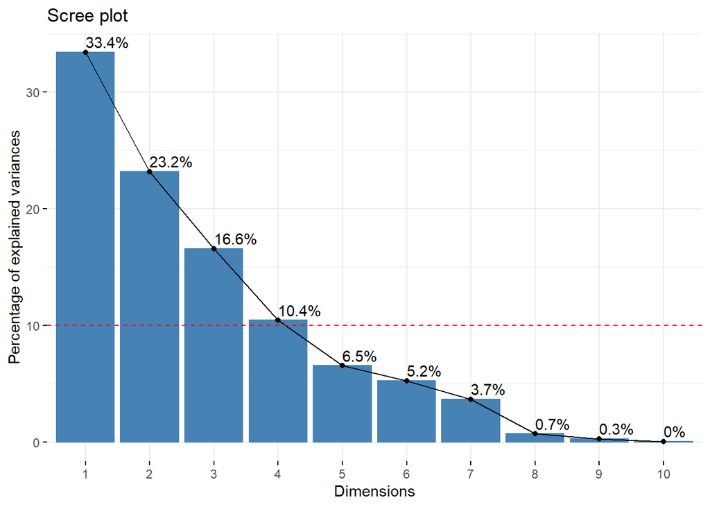

```r
library(FactoMineR)
library(factoextra)
res.pca = PCA(cereals, scale.unit = TRUE, graph = FALSE, ncp = 10,
              quali.sup = which(descCere$tipo == "categorical"))
eig.val <- get_eigenvalue(res.pca)
VPmedio = 100 * (1/nrow(eig.val))
fviz_eig(res.pca, addlabels = TRUE) +
  geom_hline(yintercept=VPmedio, linetype=2, color="red")
```

```r
kable(eig.val[1:6,])
```

|  | eigenvalue | variance.percent | cumulative.variance.percent |
| --- | --- | --- | --- |
| Dim.1 | 3.3413184 | 33.413184 | 33.41318 |
| Dim.2 | 2.3171910 | 23.171910 | 56.58509 |
| Dim.3 | 1.6570648 | 16.570647 | 73.15574 |
| Dim.4 | 1.0423060 | 10.423060 | 83.57880 |
| Dim.5 | 0.6522341 | 6.522341 | 90.10114 |
| Dim.6 | 0.5236860 | 5.236860 | 95.33800 |

```r
res.pca = PCA(cereals, scale.unit = TRUE, graph = FALSE, ncp = 4,
              quali.sup = which(descCere$tipo == "categorical"))
```

Seleccionaremos 4 PCs, que explican un 83.6% del total de variabilidad de los datos.

# 4 Validación del modelo PCA

## 4.1 Detección de anómalos con T2-Hotelling

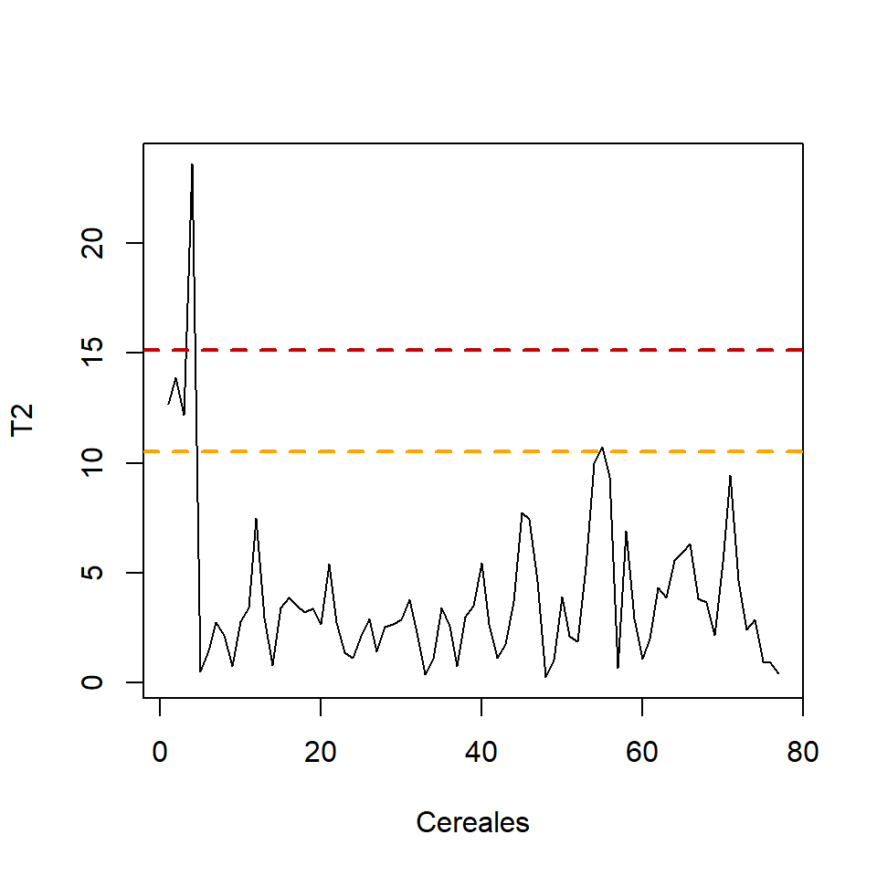

```r
K = 4
misScores = res.pca$ind$coord[,1:K]
miT2 = colSums(t(misScores**2) / eig.val[1:K,1])
I = nrow(cereals)
F95 = K*(I**2 - 1)/(I*(I - K)) * qf(0.95, K, I-K)
F99 = K*(I**2 - 1)/(I*(I - K)) * qf(0.99, K, I-K)
plot(1:length(miT2), miT2, type = "l", xlab = "Cereales", ylab = "T2")
abline(h = F95, col = "orange", lty = 2, lwd = 2)
abline(h = F99, col = "red3", lty = 2, lwd = 2)
```

```r
anomalas = which(miT2 > F95)
```

**Conclusión:** Si nos fijamos en el límite del 95%, esperamos un 5% de falsos positivos, es decir 4 cereales, y hay 5 cereales anómalos que superan el límite. Por tanto, podríamos considerar excluir la marca de cereales con mayor valor de $T^2$, es decir, All-Bran_with_Extra_Fiber, y recalcular el modelo. La mantendremos en el modelo para no repetir los cálculos y queda como ejercicio que comprobéis cómo cambiaría el modelo al quitar esta observación.

## 4.2 Distancia al modelo (SCR)

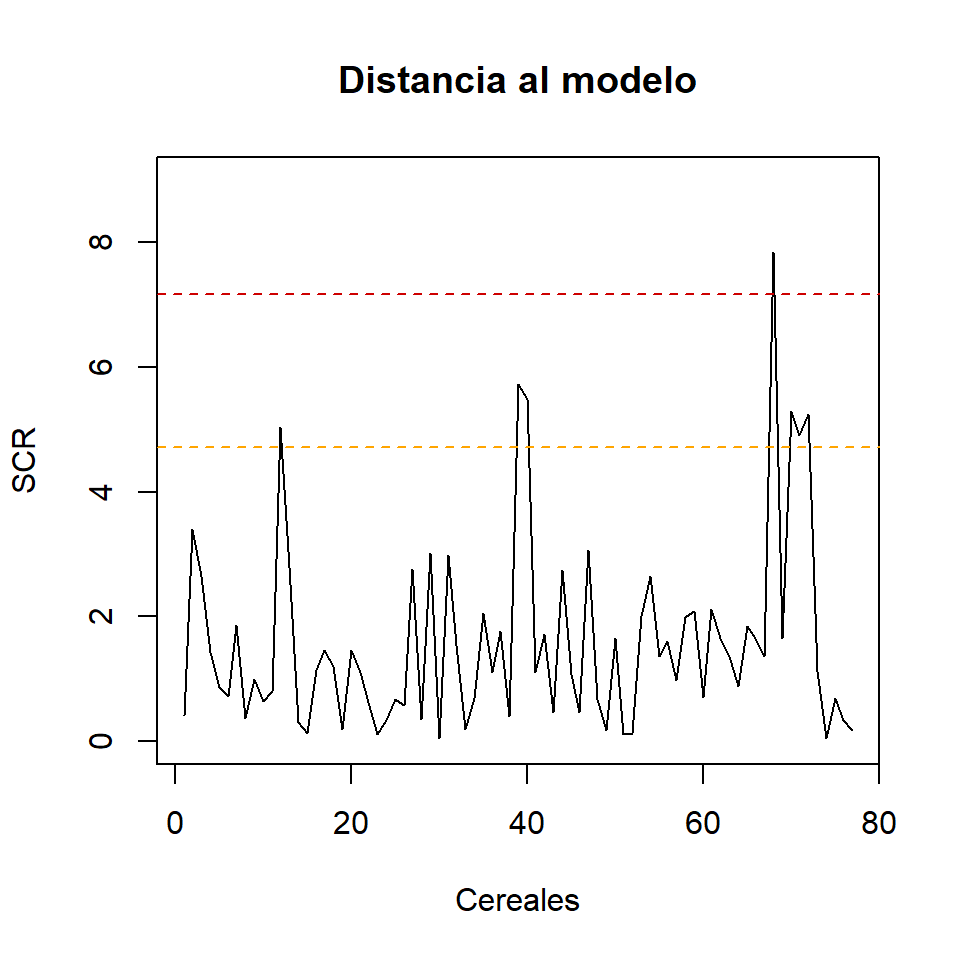

```r
misLoadings = sweep(res.pca$var$coord, 2, sqrt(res.pca$eig[1:K,1]), FUN="/")
cerealsCE = scale(cereals[,descCere$tipo == "numerical"],
                  center = TRUE, scale = TRUE)
X = as.matrix(cerealsCE)
X[is.na(X)] = 0
myE = X - misScores %*% t(misLoadings)
mySCR = rowSums(myE^2)
plot(1:length(mySCR), mySCR, type = "l", main = "Distancia al modelo",
     ylab = "SCR", xlab = "Cereales", ylim = c(0,9))
g = var(mySCR)/(2*mean(mySCR))
h = (2*mean(mySCR)^2)/var(mySCR)
chi2lim = g*qchisq(0.95, df = h)
chi2lim99 = g*qchisq(0.99, df = h)
abline(h = chi2lim, col = "orange", lty = 2)
abline(h = chi2lim99, col = "red3", lty = 2)
```

**Conclusión:** En este caso, hay 7 cereales que se salen fuera del límite del 95%, y solo 1 fuera del límite del 99%. Esta observación mal explicada por el modelo corresponde a los cereales Special_K. Queda como ejercicio ver cómo quedan representados estos cereales en el modelo PCA y qué características tienen que los hacen diferentes a las tendencias generales resumidas por el modelo.

# 5 Interpretación del modelo PCA

## 5.1 Variables: Loading plot

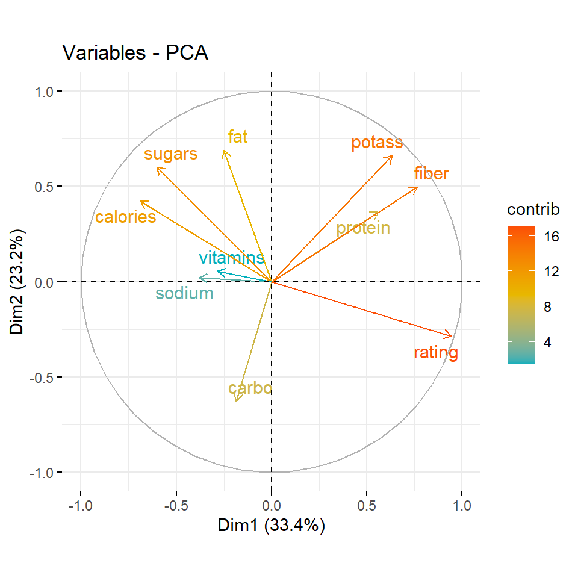

```r
fviz_pca_var(res.pca, axes = c(1,2), repel = TRUE, col.var = "contrib",
             gradient.cols = c("#00AFBB", "#E7B800", "#FC4E07"))
```

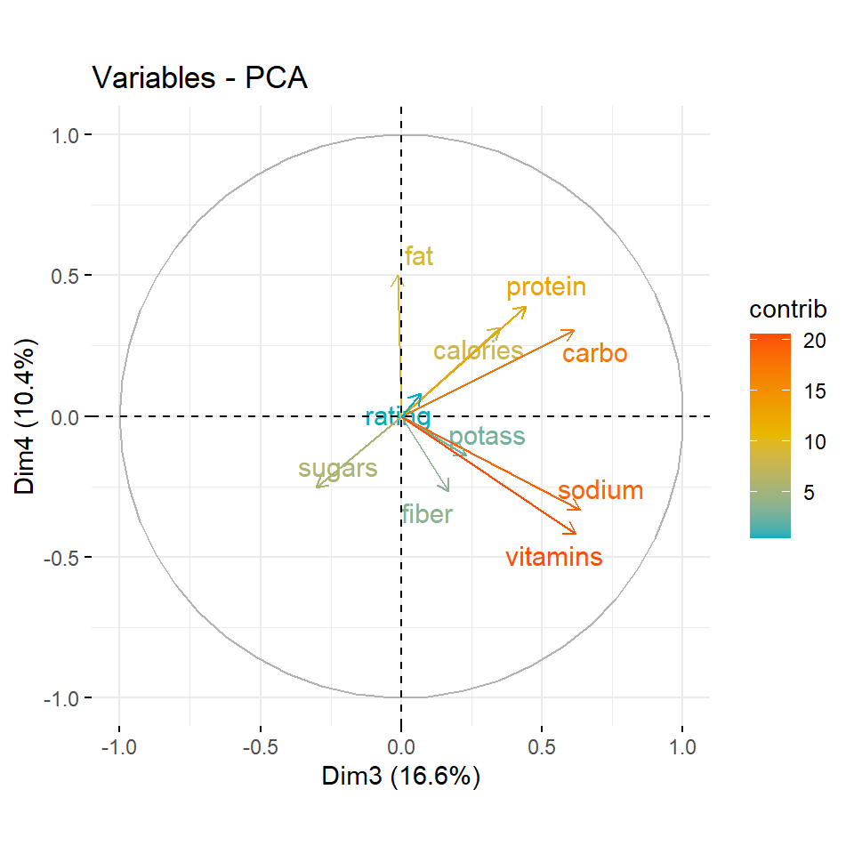

```r
fviz_pca_var(res.pca, axes = c(3,4), repel = TRUE, col.var = "contrib",
             gradient.cols = c("#00AFBB", "#E7B800", "#FC4E07"))
```

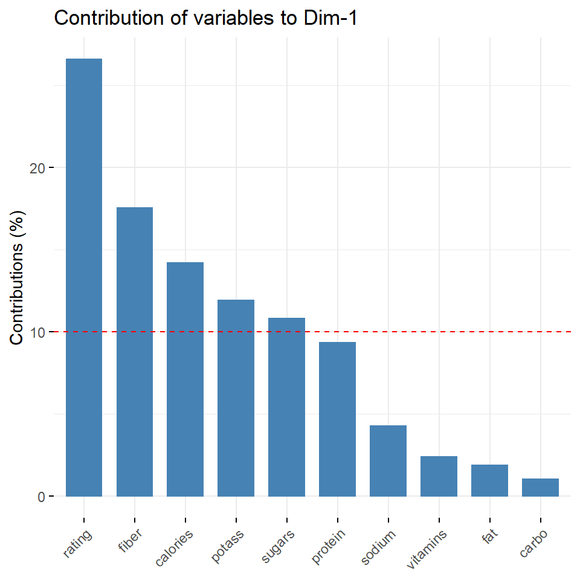

```r
fviz_contrib(res.pca, choice = "var", axes = 1)
```

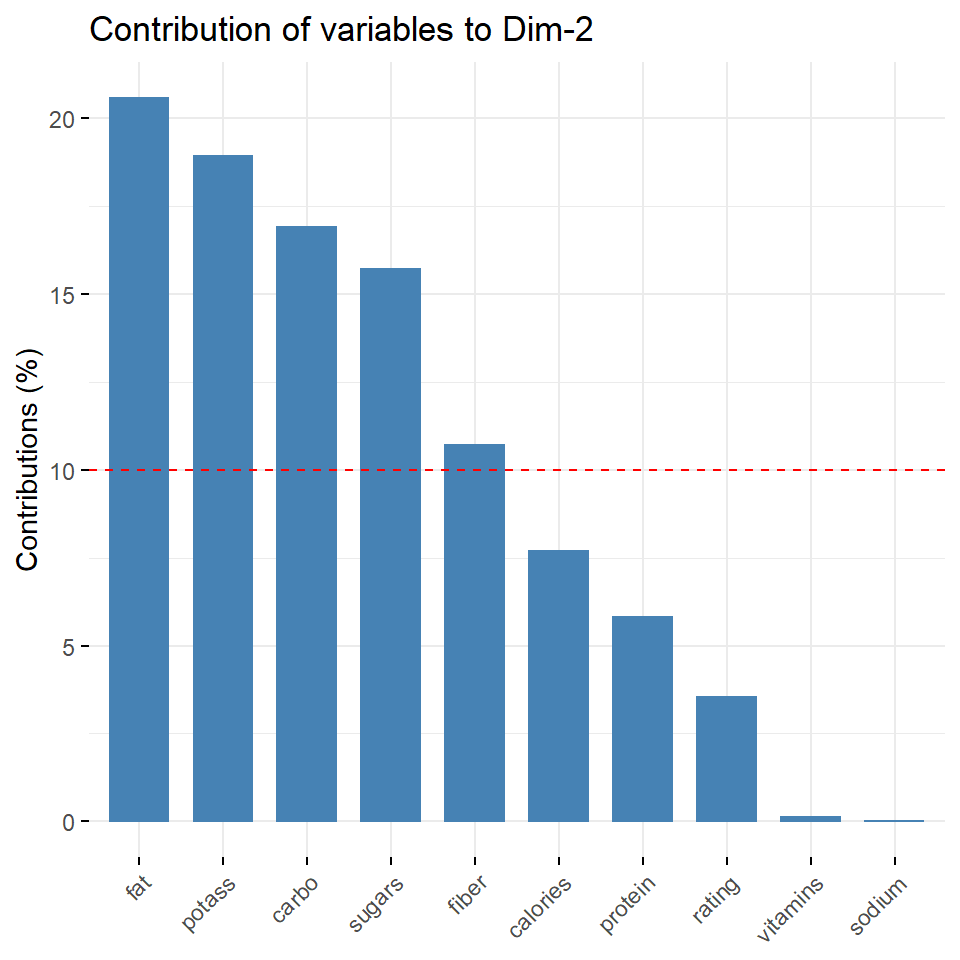

```r
fviz_contrib(res.pca, choice = "var", axes = 2)
```

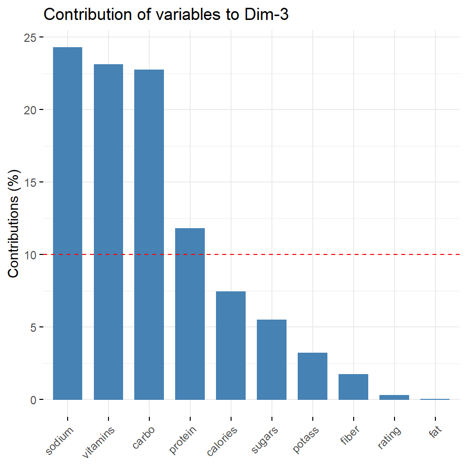

```r
fviz_contrib(res.pca, choice = "var", axes = 3)
```

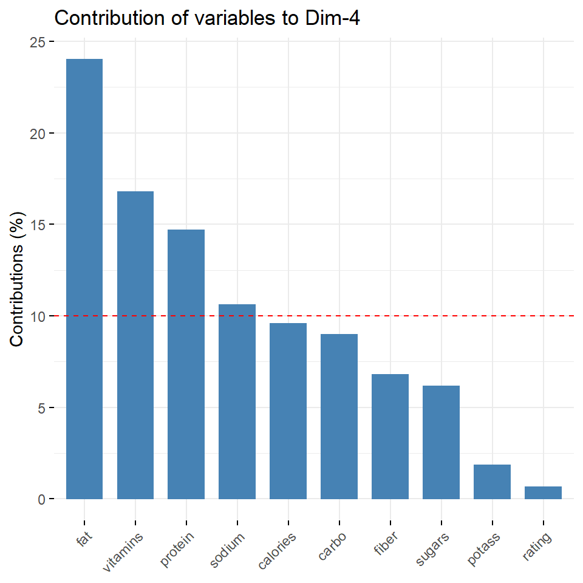

```r
fviz_contrib(res.pca, choice = "var", axes = 4)
```

## 5.2 Observaciones: Score plot

En esta sección, mostraremos solo los gráficos para las 2 primeras componentes principales. Se tienen que analizar también los gráficos correspondientes a las PC 3 y 4, de forma análoga a como se hizo para las variables. Queda como ejercicio, pues, explorar e interpretar estos gráficos.

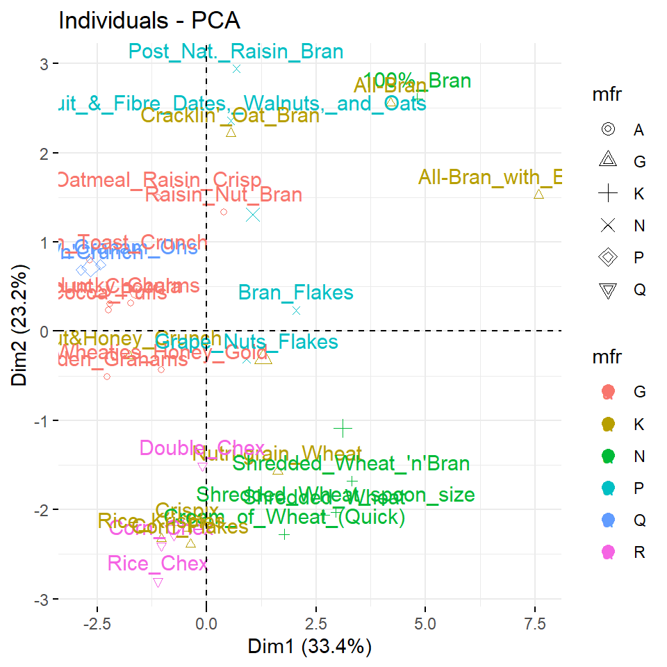

```r
fviz_pca_ind(res.pca, axes = c(1,2), geom = c("point", "text"),
             select.ind = list("cos2"=30), habillage = "mfr")
```

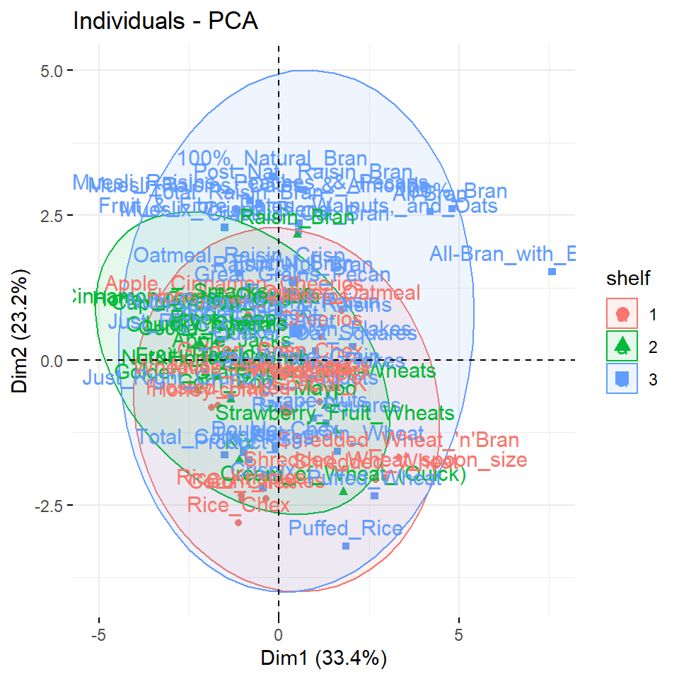

```r
fviz_pca_ind(res.pca, axes = c(1,2), geom = c("point", "text"),
             habillage = "shelf", addEllipses = TRUE)
```

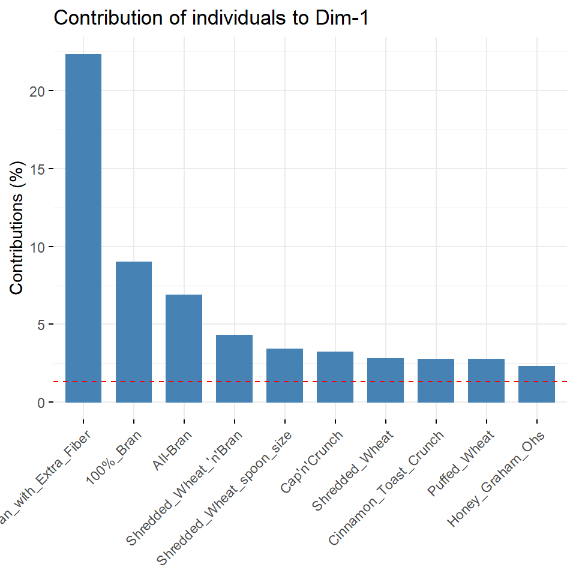

```r
fviz_contrib(res.pca, choice = "ind", axes = 1, top = 10)
```

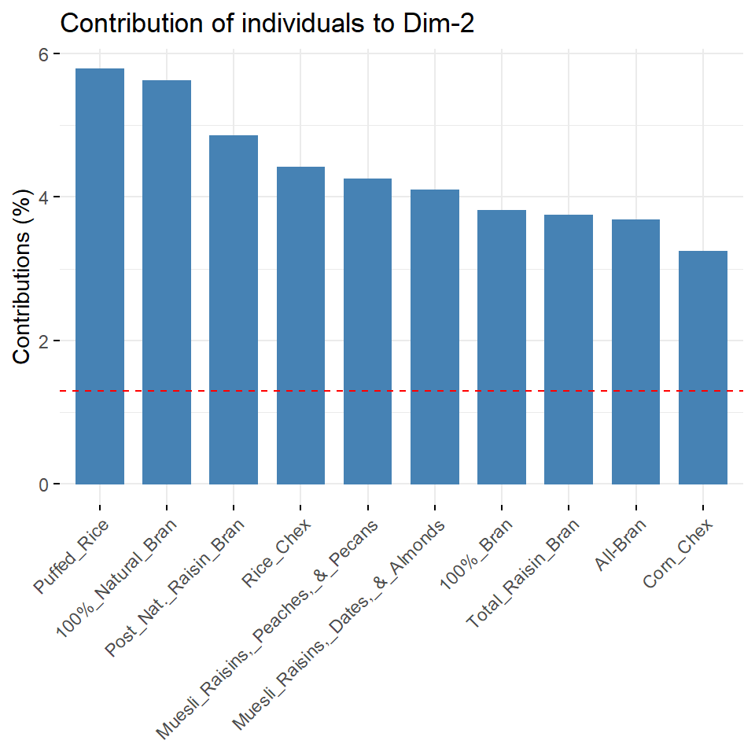

```r
fviz_contrib(res.pca, choice = "ind", axes = 2, top = 10)
```

## 5.3 Biplot

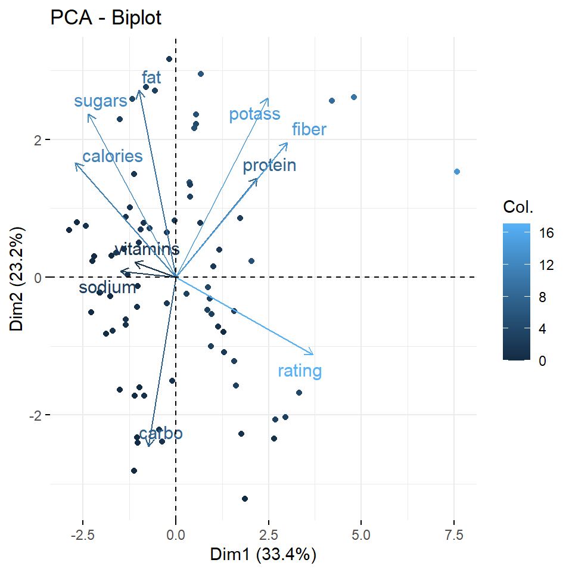

```r
fviz_pca_biplot(res.pca, axes = c(1,2), col.var = "contrib", label = "var",
                repel = TRUE, col.ind = cereals$fiber)
```